# Revisions

Alejandro Reyes

2017

```r
library(HumanDEU)
library(RColorBrewer)
library(ggplot2)
library(DEXSeq)
data("crossCoefs1", "crossCoefs2", "crossCoefs3", "crossCoefsJR1", "crossCoefsJR2", "crossCoefsJR3" )
data("dxdObjects")
data("geneTrack")
data("resultsDF")
options( ucscChromosomeNames=FALSE )
transcriptDb <- loadDb( file.path(
        system.file("extdata", package="HumanDEU"),
        "GRCh38.sqlite" ) )
```

# Plot coefficients of known exon skipping events

## ATP11B

```r
dplyr:::filter(resultsDF, label=="subsetC",
               gene == "ENSG00000058063",
               tdu > 1, padj < 0.1 )[,c("padj", "tdu")]
```

```
##   padj      tdu
## 1    0 1.648744
```

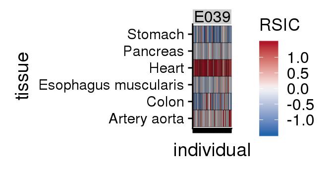

```r
plotGeneREUCs( crossCoefsJR3, "ENSG00000058063", exons=c("E039") ) +
    facet_wrap( ~exon, nrow=1 ) +
    guides( fill = guide_colorbar( title="RSIC" ) )
```

```r
coords <- range( geneTrack@range[geneTrack@range$transcript %in% "ENSG00000058063" &
                 geneTrack@range$exon %in% c("E038", "E039", "E040", "E041", "E042"),] )
start( coords ) <- start( coords ) - 100
end( coords ) <- end( coords ) + 100

ind <- levels( colData(dxd3)$individual )[32]
```

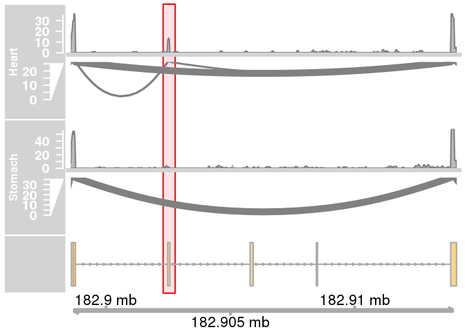

```r
samples <- HumanDEU:::getSampleIdentifiers(
          c("Heart - Left Ventricle", "Stomach"),
          ind, dxd3 )
path <- Sys.getenv("gtex")
bamFiles <- sapply( samples, function(x){
    file.path( path, "alignments", x,
        sprintf("%s_Aligned.sortedByCoord.out.bam", x ) )
} )

if(  all( file.exists(bamFiles) ) ){
#    png("sup2_clark2007_sashimi_ATP11B.png", res=300, width=3.5, height=2.5, unit="in")
    plotSashimi( bamFiles,
                geneID="ENSG00000058063",
                nameVec=c("Heart", "Stomach"),
                transcriptDb=transcriptDb, geneTrack=geneTrack, highlightOffset=200,
                coords=coords, highlight="E039", offset=0, plotTranscripts=FALSE,
                sizes=c(1, 1, .5, .3), rnaYLim=list(c(0, 35), c(0, 55) ) )
#    dev.off()
}
```

## TPD52

```r
dplyr:::filter(resultsDF, label=="subsetC",
               gene == "ENSG00000076554",
               exon %in% c("E014", "E015"),
               tdu > 1, padj < 0.1 )[,c("padj", "tdu")]
```

```
##   padj     tdu
## 1    0 1.70305
## 2    0 1.95730
```

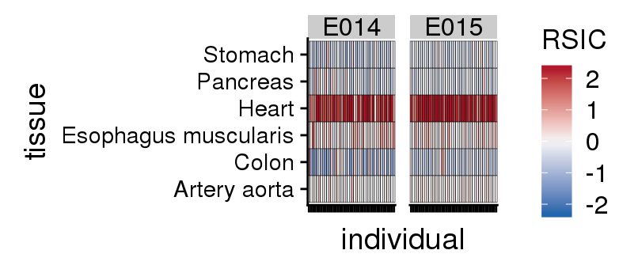

```r
#png("sup2_clark2007_reucs_TPD52.png", res=300, width=4.2, height=1.8, unit="in")
plotGeneREUCs( crossCoefsJR3, "ENSG00000076554", exons=c("E014", "E015") ) +
    facet_wrap( ~exon, nrow=1 ) +
    guides( fill = guide_colorbar( title="RSIC" ) )
```

```r
#dev.off()
```

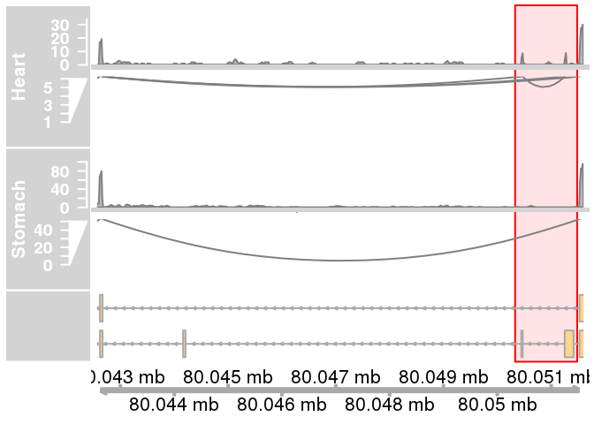

```r
coords <- range( geneTrack@range[geneTrack@range$transcript %in% "ENSG00000076554" &
                 geneTrack@range$exon %in% c("E012", "E016"),] )
start( coords ) <- start( coords ) - 1600
end( coords ) <- end( coords ) + 170

if(  all( file.exists(bamFiles) ) ){
#    png("sup2_clark2007_sashimi_TPD52.png", res=300, width=3.5, height=2.5, unit="in")
    plotSashimi( bamFiles,
                geneID="ENSG00000076554",
                nameVec=c("Heart", "Stomach"),
                transcriptDb=transcriptDb, geneTrack=geneTrack,
                coords=coords, highlight=c( "E014", "E015" ), highlightOffset=100, offset=0, plotTranscripts=TRUE,
                sizes=c(1, 1, .5, .4), lwd.sashimiMax=1, collapseTranscripts="meta")
#    dev.off()
}
```

## SLC25A3

Example of the gene SLC25A3 of figure 1 from [Wang_2008].

```r
dplyr:::filter(resultsDF, label=="subsetC",
               gene == "ENSG00000075415",
               exon %in% c("E014", "E016"),
               tdu > 1, padj < 0.1 )[,c("padj", "tdu")]
```

```
##   padj      tdu
## 1    0 2.174006
## 2    0 2.322055
```

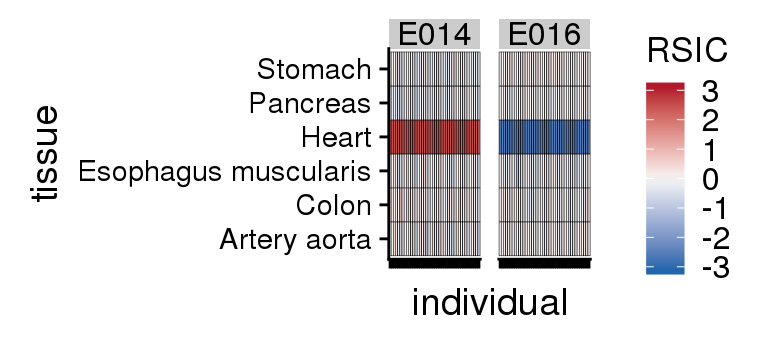

```r
#png("sup2_wang2008_reucs_SLC25A3.png", res=300, width=4, height=1.8, unit="in")
plotGeneREUCs( crossCoefsJR3, "ENSG00000075415", exons=c("E014", "E016") ) +
    facet_wrap( ~exon, nrow=1 ) +
    guides( fill = guide_colorbar( title="RSIC" ) )
```

```r
#dev.off()
```

```r
coords <- range( geneTrack@range[geneTrack@range$transcript %in% "ENSG00000075415" &
                 geneTrack@range$exon %in% c("E012", "E017"),] )

ind <- levels( colData(dxd3)$individual )[4]
ind
```

```
## [1] "GTEX-11I78"
```

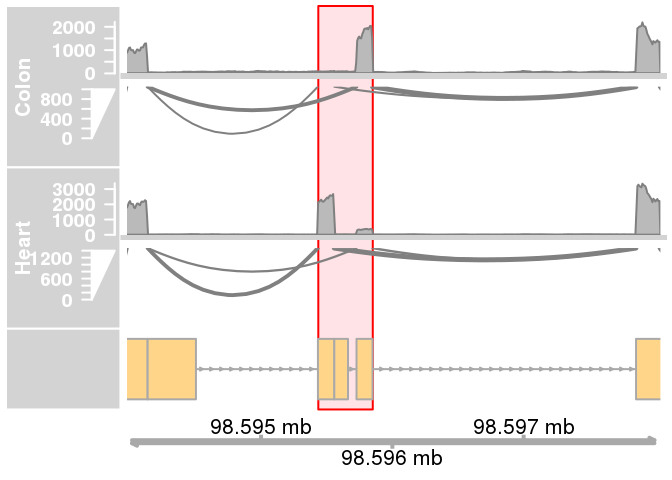

```r
samples <- HumanDEU:::getSampleIdentifiers(
          c("Colon - Transverse", "Heart - Left Ventricle"),
          ind, dxd3 )
path <- Sys.getenv("gtex")
bamFiles <- sapply( samples, function(x){
    file.path( path, "alignments", x,
        sprintf("%s_Aligned.sortedByCoord.out.bam", x ) )
} )
if(  all( file.exists(bamFiles) ) ){
#    png("sup2_wang2008_sashimi_SLC25A3.png", res=300, width=3.5, height=2.5, unit="in")
    plotSashimi( bamFiles,
                geneID="ENSG00000075415",
                nameVec=c("Colon", "Heart"),
                transcriptDb=transcriptDb, geneTrack=geneTrack,
                coords=coords, highlight=c( "E014", "E016" ), offset=0,
                sizes=c(1, 1, .5, .4), lwd.sashimiMax=2.5,
                transcriptIntrons=c("ENST00000401722", "ENST00000228318"))
#    dev.off()
}
```

## NDUFV3

[@Guerrero_Castillo_2017] described the expression of a long and a short version of the isoform

```r
dplyr:::filter(resultsDF, label == "subsetC",
               gene == "ENSG00000160194",
               exon %in% c("E008", "E009") )[,c("padj", "tdu")]
```

```
##   padj      tdu
## 1    0 2.023871
## 2    0 2.057604
```

```r
dplyr:::filter(resultsDF, label=="subsetB",
               gene == "ENSG00000160194",
               exon %in% c("E008", "E009"))[,c("padj", "tdu")]
```

```
##   padj       tdu
## 1    0 0.9351591
## 2    0 0.9076245
```

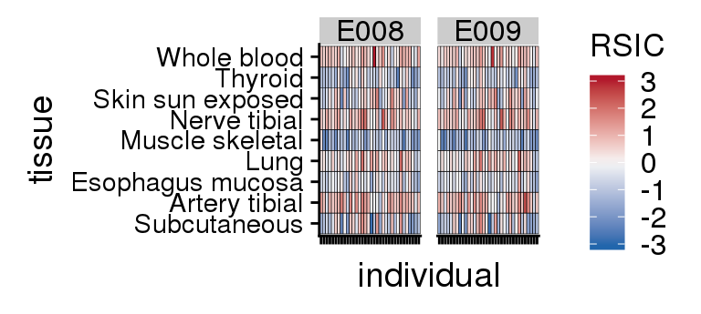

```r
#png("sup2_guerrero2017_reucs_NDUFV3subB.png", res=300, width=4, height=1.8, unit="in")
plotGeneREUCs( crossCoefsJR2, geneName="ENSG00000160194", exons=c("E008", "E009") ) +
    guides( fill = guide_colorbar( title="RSIC" ) )
```

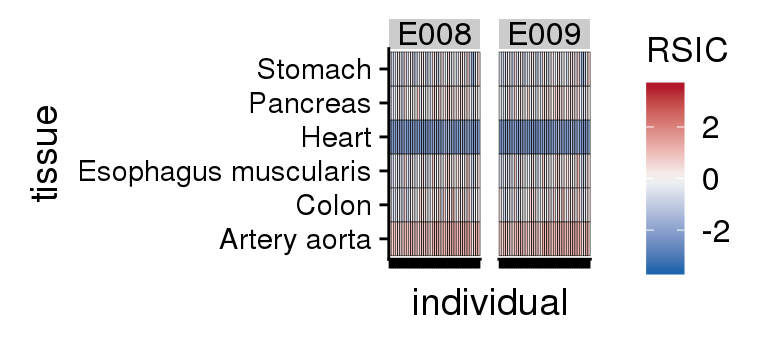

```r
#dev.off()
#png("sup2_guerrero2017_reucs_NDUFV3subC.png", res=300, width=4, height=1.8, unit="in")
plotGeneREUCs( crossCoefsJR3, geneName="ENSG00000160194", exons=c("E008", "E009") ) +
    guides( fill = guide_colorbar( title="RSIC" ) )
```

```r
#dev.off()

coords <- range( geneTrack@range[geneTrack@range$transcript %in% "ENSG00000160194" &
                 geneTrack@range$exon %in% c("E007", "E010"),] )

ind <- levels( colData(dxd2)$individual )[2]
ind
```

```
## [1] "GTEX-11DXZ"
```

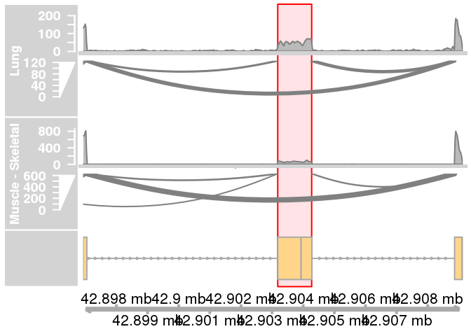

```r
samples <- HumanDEU:::getSampleIdentifiers(
          c("Lung", "Muscle - Skeletal"),
          ind, dxd2 )
path <- Sys.getenv("gtex")
bamFiles <- sapply( samples, function(x){
    file.path( path, "alignments", x,
        sprintf("%s_Aligned.sortedByCoord.out.bam", x ) )
} )

if(  all( file.exists(bamFiles) ) ){
#    png("sup2_guerrero2017_sashimi_NDUFV3subB.png", res=300, width=3.5, height=2.5, unit="in")
    plotSashimi( bamFiles,
                geneID="ENSG00000160194",
                nameVec=c("Lung", "Muscle - Skeletal"),
                transcriptDb=transcriptDb, geneTrack=geneTrack,
                coords=coords, highlight=c( "E008", "E009" ), offset=0,
                sizes=c(1, 1, .5, .4) )
#    dev.off()
}
```

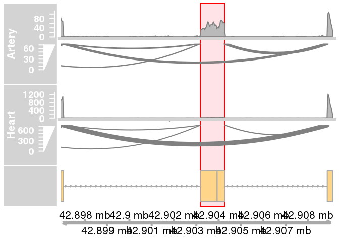

```r
ind <- levels( colData(dxd3)$individual )[3]

samples <- HumanDEU:::getSampleIdentifiers(
          c("Artery - Aorta", "Heart - Left Ventricle"),
          ind, dxd3 )
path <- Sys.getenv("gtex")
bamFiles <- sapply( samples, function(x){
    file.path( path, "alignments", x,
        sprintf("%s_Aligned.sortedByCoord.out.bam", x ) )
} )

if(  all( file.exists(bamFiles) ) ){
#    png("sup2_guerrero2017_sashimi_NDUFV3subC.png", res=300, width=3.5, height=2.5, unit="in")
    plotSashimi( bamFiles,
                geneID="ENSG00000160194",
                nameVec=c("Artery", "Heart"),
                transcriptDb=transcriptDb, geneTrack=geneTrack,
                coords=coords, highlight=c( "E008", "E009" ), offset=0,
                sizes=c(1, 1, .5, .4) )
#    dev.off()
}
```

## SGCE

[@Ritz_2010] example of an exon included mainly in cerebellum.

```r
dplyr:::filter( resultsDF, label == "subsetA",
               gene == "ENSG00000127990",
               padj < 0.1,
               exon %in% c("E006"),
               tdu > 1 )
```

```
##              gene exon     mean  esMeans      tdu        sds pvals   label
## 1 ENSG00000127990 E006 108.3306 86.89651 1.208483 0.01826977     0 subsetA
##   padj corRiscReuc
## 1    0   0.9471786
```

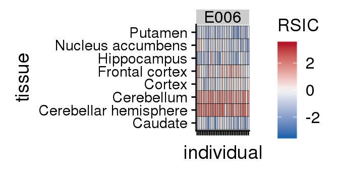

```r
#png("sup2_ritz2010_reucs_SGCE.png", res=300, width=3.5, height=1.8, unit="in")
plotGeneREUCs( crossCoefsJR1, geneName="ENSG00000127990", exons=c("E006")) +
    guides( fill = guide_colorbar( title="RSIC" ) )
```

```r
#dev.off()
```

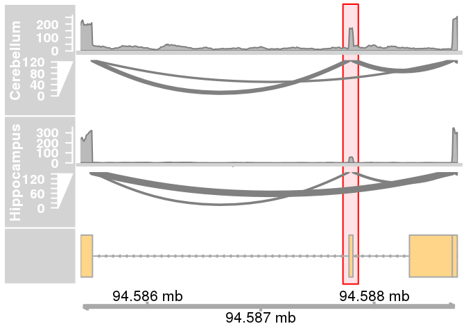

```r
ind <- levels( colData(dxd1)$individual )[1]
samples <- HumanDEU:::getSampleIdentifiers(
          c("Brain - Cerebellum", "Brain - Hippocampus"),
          ind, dxd1 )

coords <- range( geneTrack@range[geneTrack@range$transcript %in% "ENSG00000127990" &
                 geneTrack@range$exon %in% c("E005", "E008"),] )

path <- Sys.getenv("gtex")
bamFiles <- sapply( samples, function(x){
    file.path( path, "alignments", x,
        sprintf("%s_Aligned.sortedByCoord.out.bam", x ) )
} )

if(  all( file.exists(bamFiles) ) ){
#    png("sup2_ritz2010_sashimi_SGCE.png", res=300, width=3.5, height=2.5, unit="in")
    plotSashimi( bamFiles,
                geneID="ENSG00000127990",
                nameVec=c("Cerebellum", "Hippocampus"),
                transcriptDb=transcriptDb, geneTrack=geneTrack,
                coords=coords, highlight=c( "E006" ), highlightOffset=50,
                sizes=c(1, 1, .5, .4) )
#    dev.off()
}
```

## MYO1C

[@Sielski_2014] reported the usage of an alternative 5’ exons for the gene MYO1C. Exon E053 (labeled “Exon -1” in that paper that translated the peptide MRYRA) tissue-dependent usage based than the RT-PCR presented in their Figure 1.

```r
dplyr:::filter( resultsDF, label == "subsetC",
               gene == "ENSG00000197879",
               padj < 0.1,
               exon %in% c( "E053", "E061" ),
               tdu > 1 )[,c("tdu", "padj")]
```

```
##        tdu         padj
## 1 1.013408 2.782159e-13
## 2 1.322143 0.000000e+00
```

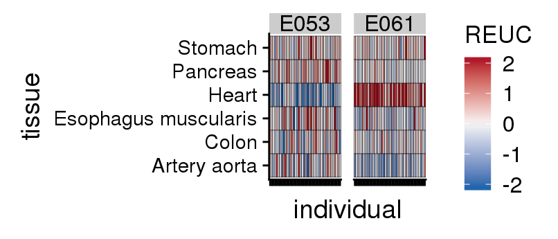

```r
#png("sup2_sielski2013_reucs_MYO1C.png", res=300, width=4.2, height=1.8, unit="in")
plotGeneREUCs( crossCoefs3, geneName="ENSG00000197879", exons=c("E053", "E061") ) +
    guides( fill = guide_colorbar( title="REUC" ) )
```

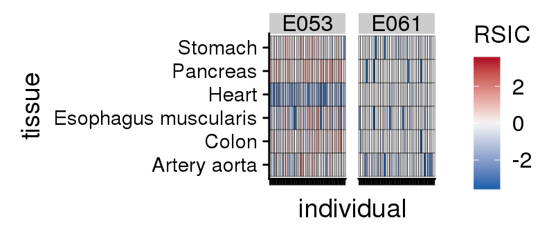

```r
#dev.off()
#png("sup2_sielski2013_rsics_MYO1C.png", res=300, width=4.2, height=1.8, unit="in")
plotGeneREUCs( crossCoefsJR3, geneName="ENSG00000197879", exons=c("E053", "E061") ) +
    guides( fill = guide_colorbar( title="RSIC" ) )
```

```r
#dev.off()
```

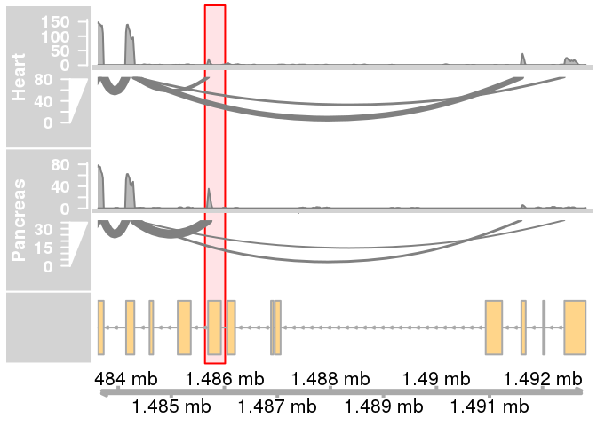

```r
ind <- levels( colData(dxd3)$individual )[40]
samples <- HumanDEU:::getSampleIdentifiers(
          c( "Heart - Left Ventricle", "Pancreas" ),
          ind, dxd3 )

coords <- range( geneTrack@range[geneTrack@range$transcript %in% "ENSG00000197879" &
                 geneTrack@range$exon %in% c("E049", "E061"),] )

path <- Sys.getenv("gtex")
bamFiles <- sapply( samples, function(x){
    file.path( path, "alignments", x,
        sprintf("%s_Aligned.sortedByCoord.out.bam", x ) )
} )
if(  all( file.exists(bamFiles) ) ){
#    png("sup2_sielski2013_sashimi_MYO1C.png", res=300, width=3.5, height=2.5, unit="in")
    plotSashimi( bamFiles,
                geneID="ENSG00000197879",
                nameVec=c("Heart", "Pancreas"),
                transcriptDb=transcriptDb, geneTrack=geneTrack,
                coords=coords, highlight=c( "E053" ), offset=0, highlightOffset=70,
                transcriptIntrons=c("ENST00000438665", "ENST00000359786","ENST00000361007"),
                sizes=c(1, 1, .5, .4) )
#    dev.off()
}
```

## ATP5C1

[@Hayakawa_2001] reported an exon that is specifically excluded in muscle tissues as compared to non-muscle tissues for an exon of the gene ATP5C1.

```r
dplyr:::filter( resultsDF, label == "subsetB",
               gene == "ENSG00000165629",
               padj < 0.1,
               exon %in% c( "E021" ),
               tdu > 1 )[,c("tdu", "padj")]
```

```
##        tdu padj
## 1 2.593405    0
```

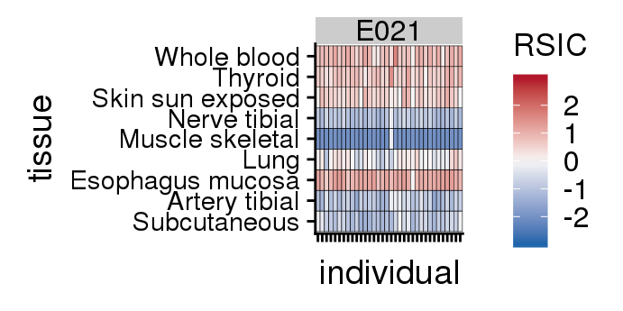

```r
ind <- levels( colData(dxd2)$individual )[1]
samples <- HumanDEU:::getSampleIdentifiers(
          c( "Muscle - Skeletal", "Esophagus - Mucosa"),
          ind, dxd2 )

#png("sup2_hayakawa2001_reucs_ATP5C1.png", res=300, width=3.6, height=1.8, unit="in")
plotGeneREUCs( crossCoefsJR2, "ENSG00000165629", exons="E021")+
        guides( fill = guide_colorbar( title="RSIC" ) )
```

```r
#dev.off()

coords <- range( geneTrack@range[geneTrack@range$transcript %in% "ENSG00000165629" &
                                 geneTrack@range$exon %in% c("E020", "E022"),] )
```

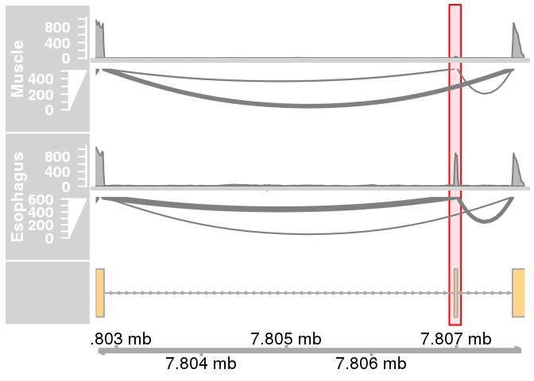

```r
rng <- rowRanges( dxd2 )["ENSG00000165629:E021",]
start(rng) <- start(rng) - 50
end(rng) <- end(rng) + 50

path <- Sys.getenv("gtex")
bamFiles <- sapply( samples, function(x){
    file.path( path, "alignments", x,
        sprintf("%s_Aligned.sortedByCoord.out.bam", x ) )
} )
if(  all( file.exists(bamFiles) ) ){
#    png("sup2_hayakawa2001_sashimi_ATP5C1.png", res=300, width=3.5, height=2.5, unit="in")
    plotSashimi( bamFiles,
                geneID="ENSG00000165629",
                nameVec=c("Muscle", "Esophagus"),
                transcriptDb=transcriptDb, geneTrack=geneTrack,
                coords=coords, #highlight=c( "E021" ),
                highlight=rng,
                sizes=c(1, 1, .5, .4) )
#    dev.off()
}
```

## ANK3

[@Hopitzan_2005] reported muscle-specific isoform expression of the gene Ankyrin-3. This is an example of a strong isoform switch where most exons are used in a tissue-dependent manner due to a combination of alternative splicing and alternative transcriptional events.

```r
res <- dplyr:::filter( resultsDF, label == "subsetB",
               gene == "ENSG00000151150",
               padj < 0.1,
               tdu > 1 )

exns <- as.character( res[head(order( res$tdu, decreasing=TRUE ), 8),"exon"] )

nrow( dplyr:::filter( resultsDF, label == "subsetB",
               gene == "ENSG00000151150" ) )
```

```
## [1] 109
```

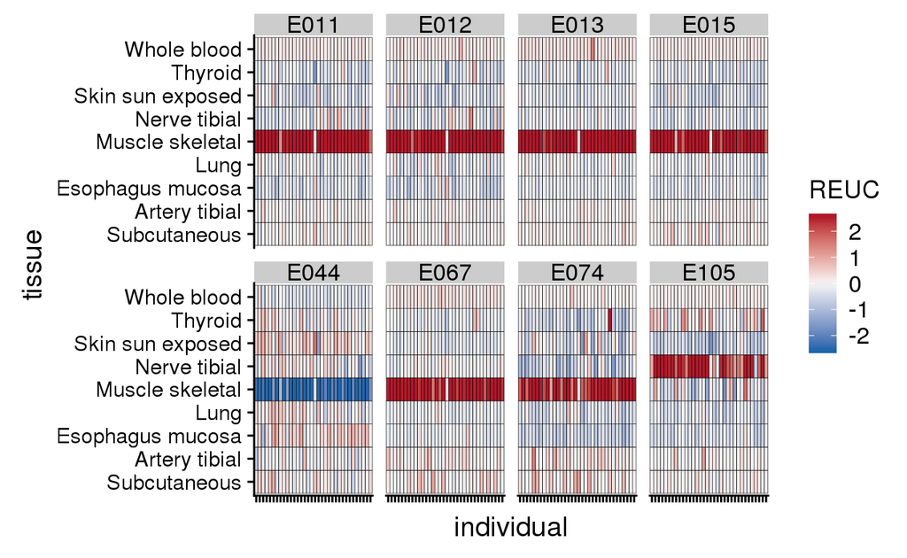

```r
#png("sup2_hopitzan2005_reucs_ANK3.png", res=300, width=6.5, height=4, unit="in")
plotGeneREUCs( crossCoefs2, "ENSG00000151150", exons=exns ) +
    facet_wrap( ~exon, nrow=2 )
```

```r
#dev.off()
```

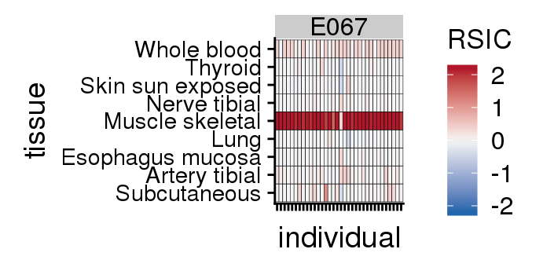

```r
#png("sup2_hopitzan2005_rsics_ANK3.png", res=300, width=3.6, height=1.8, unit="in")
plotGeneREUCs( crossCoefsJR2, "ENSG00000151150", exons="E067" ) +
    facet_wrap( ~exon, nrow=2 ) +
    guides( fill = guide_colorbar( title="RSIC" ) )
```

```r
                                        #dev.off()
```

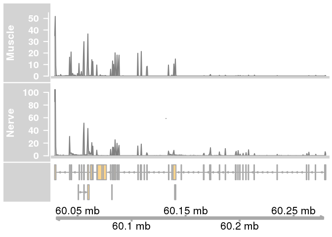

```r
ind <- levels( colData(dxd2)$individual )[1]
samples <- HumanDEU:::getSampleIdentifiers(
          c( "Muscle - Skeletal", "Nerve - Tibial"),
          ind, dxd2 )

path <- Sys.getenv("gtex")
bamFiles <- sapply( samples, function(x){
    file.path( path, "alignments", x,
        sprintf("%s_Aligned.sortedByCoord.out.bam", x ) )
} )
coords <- range( geneTrack@range[geneTrack@range$transcript %in% "ENSG00000151150" &
                 geneTrack@range$exon %in% c("E002", "E101"),] )
if(  all( file.exists(bamFiles) ) ){
#    png("sup2_hopitzan2005_sashimi_ANK3_1.png", res=300, width=3.5, height=2.5, unit="in")
    plotSashimi( bamFiles,
                geneID="ENSG00000151150",
                nameVec=c("Muscle", "Nerve"),
                transcriptDb=transcriptDb, geneTrack=geneTrack,
                coords=coords,
                offset=0, type="coverage",
                rnaYLim=list(c(0, 55), c(0, 100)),
                sizes=c(1, 1, .5, .4) )
#    dev.off()
}
```

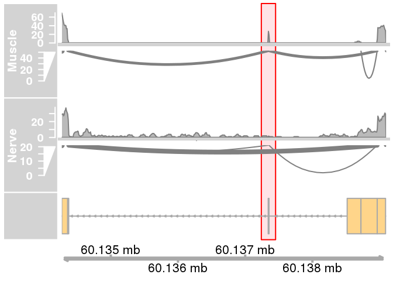

```r
coords <- range( geneTrack@range[geneTrack@range$transcript %in% "ENSG00000151150" &
                 geneTrack@range$exon %in% c("E065", "E070"),] )
rn <- rowRanges(dxd2)["ENSG00000151150:E067",]

if(  all( file.exists(bamFiles) ) ){
#    png("sup2_hopitzan2005_sashimi_ANK3_2.png", res=300, width=3.5, height=2.5, unit="in")
    plotSashimi( bamFiles,
                geneID="ENSG00000151150",
                nameVec=c("Muscle", "Nerve"),
                transcriptDb=transcriptDb, geneTrack=geneTrack,
                coords=coords, highlight="E067",
                highlightOffset=100,
                #offset=10,
                sizes=c(1, 1, .5, .4) )
#    dev.off()
}
```

## MEF2C

[@Hakim_2010] reported using RT-PCR a mutually exclusive splicing event that was exclusive to skeletal muscle.

```r
dplyr:::filter( resultsDF, label == "subsetB",
               gene == "ENSG00000081189",
               padj < 0.1,
               tdu > 1 ,
               exon %in% c("E031", "E032", "E033", "E034", "E035", "E036", "E037")
               )[c("padj", "tdu")]
```

```
##           padj      tdu
## 1 0.000000e+00 2.744713
## 2 0.000000e+00 2.831589
## 3 0.000000e+00 1.910593
## 4 0.000000e+00 1.914549
## 5 0.000000e+00 2.036635
## 6 0.000000e+00 1.751693
## 7 3.063135e-14 1.543144
```

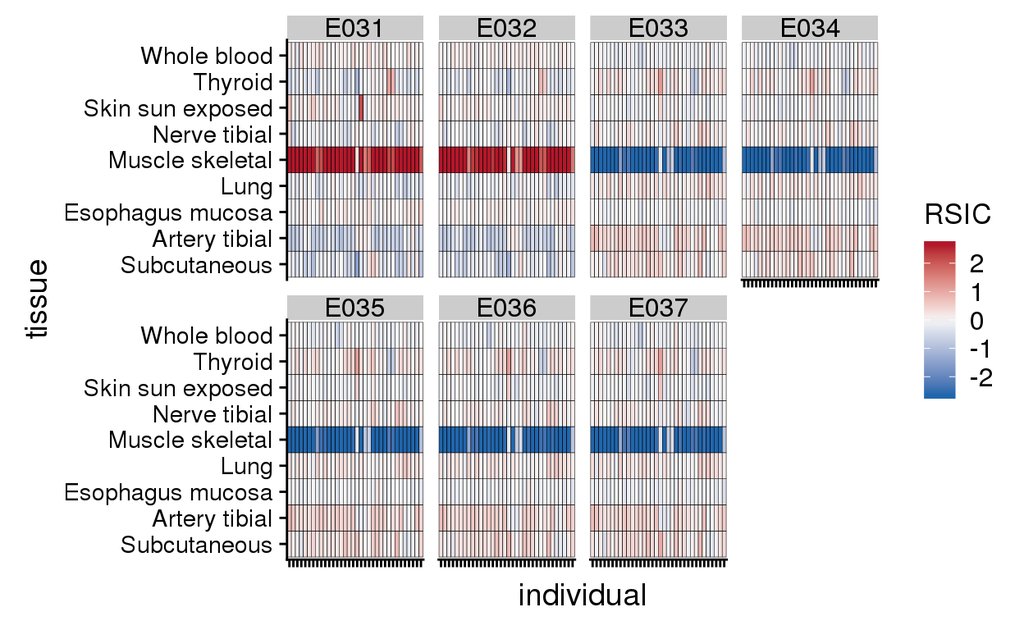

```r
#png("sup2_hakim2010_rsics_MEF2C.png", res=300, width=6.5, height=4, unit="in")
plotGeneREUCs( crossCoefsJR2, "ENSG00000081189",
              exons=c("E031", "E032", "E033", "E034", "E035", "E036", "E037") ) +
        facet_wrap( ~ exon, nrow=2 ) +
        guides( fill = guide_colorbar( title="RSIC" ) )
```

```r
#dev.off()
```

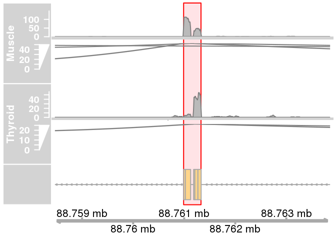

```r
ind <- levels( colData(dxd2)$individual )[1]
samples <- HumanDEU:::getSampleIdentifiers(
          c( "Muscle - Skeletal", "Thyroid"),
          ind, dxd2 )
path <- Sys.getenv("gtex")
bamFiles <- sapply( samples, function(x){
    file.path( path, "alignments", x,
        sprintf("%s_Aligned.sortedByCoord.out.bam", x ) )
} )

coords <- range( geneTrack@range[geneTrack@range$transcript %in% "ENSG00000081189" &
                 geneTrack@range$exon %in% c("E031", "E037"),] )
start(coords) <- start( coords ) - 2500
end(coords) <- end( coords ) + 2500
if(  all( file.exists(bamFiles) ) ){
#    png("sup2_hakim2010_sashimi_MEF2C.png", res=300, width=3.5, height=2.5, unit="in")
    plotSashimi( bamFiles,
                geneID="ENSG00000081189",
                nameVec=c("Muscle", "Thyroid"),
                transcriptDb=transcriptDb, geneTrack=geneTrack,
                coords=coords, highlight=c("E031", "E037"),
                offset=20, lwd.sashimiMax=1.2, sashimiHeight=.1,
                sizes=c(1, 1, .5, .4) )
#    dev.off()
}
```

## KSR1

```r
dplyr:::filter( resultsDF, label == "subsetA",
               gene == "ENSG00000141068",
               exon %in%
               padj < 0.1,
               exon %in% c("E045", "E046"),
               tdu > 1 )[,c("tdu", "padj")]
```

```
##        tdu padj
## 1 1.153833    0
## 2 1.184380    0
```

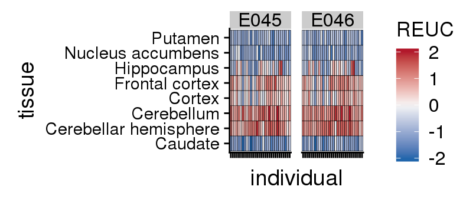

```r
#png("sup2_muller2000_rsics_KSR1.png", res=300, width=4.2, height=1.8, unit="in")
plotGeneREUCs( crossCoefsJR1, "ENSG00000141068", exons=c("E045", "E046"))
```

```r
                                        #dev.off()
```

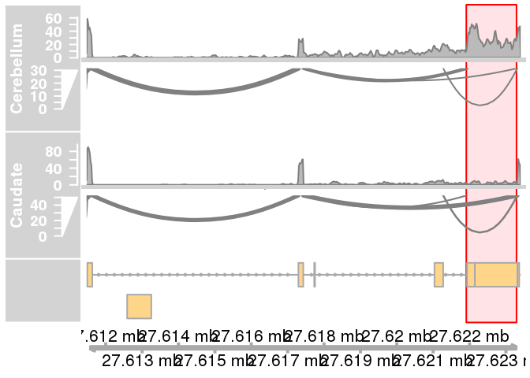

```r
ind <- levels( colData(dxd1)$individual )[7]
samples <- HumanDEU:::getSampleIdentifiers(
          c( "Brain - Cerebellum", "Brain - Caudate (basal ganglia)"),
          ind, dxd1 )

path <- Sys.getenv("gtex")
bamFiles <- sapply( samples, function(x){
    file.path( path, "alignments", x,
        sprintf("%s_Aligned.sortedByCoord.out.bam", x ) )
} )
coords <- range( geneTrack@range[geneTrack@range$transcript %in% "ENSG00000141068" &
                 geneTrack@range$exon %in% c("E041", "E047"),] )
if(  all( file.exists(bamFiles) ) ){
#    png("sup2_muller2000_sashimi_KSR1.png", res=300, width=3.5, height=2.5, unit="in")
    plotSashimi( bamFiles,
                geneID="ENSG00000141068",
                nameVec=c("Cerebellum", "Caudate"),
                transcriptDb=transcriptDb, geneTrack=geneTrack,
                coords=coords, highlight=c("E045", "E046"),
                offset=20, #lwd.sashimiMax=1.2, sashimiHeight=.1,
                sizes=c(1, 1, .5, .4) )
#    dev.off()
}
```